# Mean and Variance Analysis

Deviprasad Saka

2024-02-25

```r
# Provide the file path to CSV file
file_path <- "D:/Multivariate Analysis/Assignment-1/train US new.csv"

# Import the CSV file into R
data <- read.csv(file_path)

# View the imported data
#print(data)
```

```r
#Analyzing the univariate mean and variance of the “Air Quality index” variable
library(ggplot2)

# Calculate mean and variance for Air Quality Index
mean_AQI <- mean(data$Air_Quality_Index)
variance_AQI <- var(data$Air_Quality_Index)

print(paste("Mean for Total AQI:", mean_AQI))
```

```
## [1] "Mean for Total AQI: 38.0366972477064"
```

```r
print(paste("Variance for Total AQI:", variance_AQI))
```

```
## [1] "Variance for Total AQI: 1317.73762142472"
```

Question-1 : How does the mean of Total Air Quality Index readings gives information about Air Quality? Ans:The mean (average) of Total Air Quality Index readings, which is approximately 38.03, provides us with a typical or central value representing the air quality across different locations. This information is crucial for understanding the overall level of air quality and can be used for decision-making in various ways. For example, policymakers and public health officials can use the mean to assess the general air quality conditions in a region, prioritize areas for air quality improvement initiatives, and allocate resources for monitoring and addressing air pollution.

Question-2 : Considering the variance of Total Air Quality Index readings, how does the magnitude of variance indicate the spread or variability in air quality across different locations? Ans: The variance of Total Air Quality Index readings, which is approximately 1317.73, indicates the spread or variability in air quality across different locations. A higher variance suggests that the Total Air Quality Index readings are more spread out from each other, with some locations experiencing significantly higher or lower air quality compared to the mean. This information is important for developing targeted strategies for air quality management and public health interventions

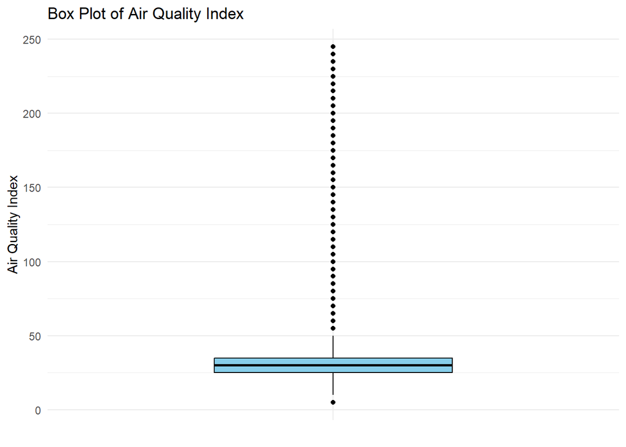

```r
library(ggplot2)

ggplot(data, aes(x = "", y = Air_Quality_Index)) +
  geom_boxplot(width = 0.5,  # Adjust the width of the boxes
               fill = "skyblue", color = "black",  # Set fill and outline color
               notch = FALSE,  # Disable notches
               coef = 1.5) +   # Adjust coefficient for determining whisker length
  labs(title = "Box Plot of Air Quality Index", x = "", y = "Air Quality Index") +
  theme_minimal() +  # Apply a minimal theme for better visual clarity
  theme(axis.text.x = element_blank())  # Remove x-axis labels for better appearance
```

Based on the plot, the box plot of the Air Quality Index (AQI) indicates the presence of outliers. The outliers are represented by the extended lines beyond the “whiskers” of the box plot, denoted by the dot symbols. These symbols suggest the presence of unusually high AQI values that deviate from the overall pattern of the data. Outliers in the context of a box plot can provide valuable insights into extreme air quality conditions that may require special attention or investigation.

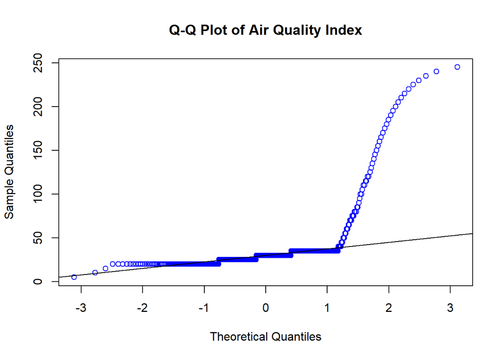

```r
# Q-Q plot for Air Quality Index
qqnorm(data$Air_Quality_Index, main = "Q-Q Plot of Air Quality Index", col = "blue")  # Adding color
qqline(data$Air_Quality_Index)
```

The Q-Q plot, or quantile-quantile plot, is a graphical tool used to assess whether a dataset follows a certain theoretical distribution, such as the normal distribution. In this specific case, the Q-Q plot is representing the distribution of the air quality index. Theoretical quantiles are plotted against sample quantiles, allowing for a visual comparison between the distribution of the air quality index and the theoretical distribution. This comparison helps in determining if the air quality index data follows a specific theoretical distribution or if it deviates from it. From the plot we can clearly observe the outliers.

T.Test:

```r
#Data: The analysis was performed on the "Air_Quality_Index" and "Healthcare_Index" variables from the dataset.
# Perform t-test
t_test_result <- t.test(data$Air_Quality_Index, data$Healthcare_Index)

# Print the t-test result
print(t_test_result)
```

```
##
##  Welch Two Sample t-test
##
## data:  data$Air_Quality_Index and data$Healthcare_Index
## t = -33.996, df = 635.25, p-value < 2.2e-16
## alternative hypothesis: true difference in means is not equal to 0
## 95 percent confidence interval:
##  -58.22935 -51.86974
## sample estimates:
## mean of x mean of y
##  38.03670  93.08624
```

The result of the t-test between “Air_Quality_Index” and “Healthcare_Index” variables is as follows:

Test Statistic (t): The calculated t-value is -33.996.

Degrees of Freedom (df): The degrees of freedom for the t-distribution are approximately 635.25.

p-value: The p-value is reported as less than 2.2e-16 (essentially zero), indicating strong evidence against the null hypothesis. This means that there is a statistically significant difference in the means of the two variables.

Alternative Hypothesis: The alternative hypothesis states that the true difference in means is not equal to zero, which implies that there is a difference in means between “Air_Quality_Index” and “Healthcare_Index”.

95% Confidence Interval: The 95% confidence interval for the difference in means is reported as (-58.22935, -51.86974). This interval suggests that we are 95% confident that the true difference in means between the two variables falls within this range.

Sample Estimates: The sample mean of “Air_Quality_Index” is 38.03670, and the sample mean of “Healthcare_Index” is 93.08624.

Meaning based on the result:

The p-value is extremely small, indicating strong evidence against the null hypothesis of no difference in means between “Air_Quality_Index” and “Healthcare_Index”. Therefore, we reject the null hypothesis in favor of the alternative hypothesis. The negative t-value suggests that the mean of “Healthcare_Index” is significantly higher than the mean of “Air_Quality_Index”. The 95% confidence interval for the difference in means does not include zero, further supporting the conclusion that there is a statistically significant difference in means between the two variables. In summary, this result suggests that there is a significant difference in means between “Air_Quality_Index” and “Healthcare_Index”, with “Healthcare_Index” having a higher mean compared to “Air_Quality_Index”.

F.Test:

```r
# Perform F-test between Air_Quality_Index and Healthcare_Index
f_test_result <- var.test(data$Air_Quality_Index, data$Healthcare_Index)

# Print F-test result
print(f_test_result)
```

```
##
##  F test to compare two variances
##
## data:  data$Air_Quality_Index and data$Healthcare_Index
## F = 11.839, num df = 544, denom df = 544, p-value < 2.2e-16
## alternative hypothesis: true ratio of variances is not equal to 1
## 95 percent confidence interval:
##  10.00587 14.00837
## sample estimates:
## ratio of variances
##           11.83917
```

The F-test result comparing the variances of “Air_Quality_Index” and “Healthcare_Index” indicates that there is a significant difference in the variability (variance) between these two variables.

F-value: The F-value of 11.839 indicates the ratio of variances between the two variables. This value is calculated by dividing the variance of “Air_Quality_Index” by the variance of “Healthcare_Index”.

p-value: The p-value is extremely small (p < 2.2e-16), indicating strong evidence against the null hypothesis that the variances of “Air_Quality_Index” and “Healthcare_Index” are equal. In other words, there is very strong evidence to suggest that the variability of “Air_Quality_Index” differs significantly from the variability of “Healthcare_Index”.

Confidence Interval: The 95% confidence interval for the ratio of variances (10.00587 to 14.00837) indicates the range within which the true ratio of variances between the two variables is likely to fall. Since this interval does not include 1, it further supports the conclusion that the variances are significantly different.

Explanation: The F-test result suggests that the variability in “Air_Quality_Index” is significantly different from the variability in “Healthcare_Index”. In other words, the data points in “Air_Quality_Index” are spread out more or less than the data points in “Healthcare_Index”. This could imply that the range or dispersion of values in “Air_Quality_Index” is either wider or narrower compared to “Healthcare_Index”. This information could be valuable when considering factors related to air quality and healthcare provision, indicating potentially different levels of variability or consistency in these domains.

Box Plot:

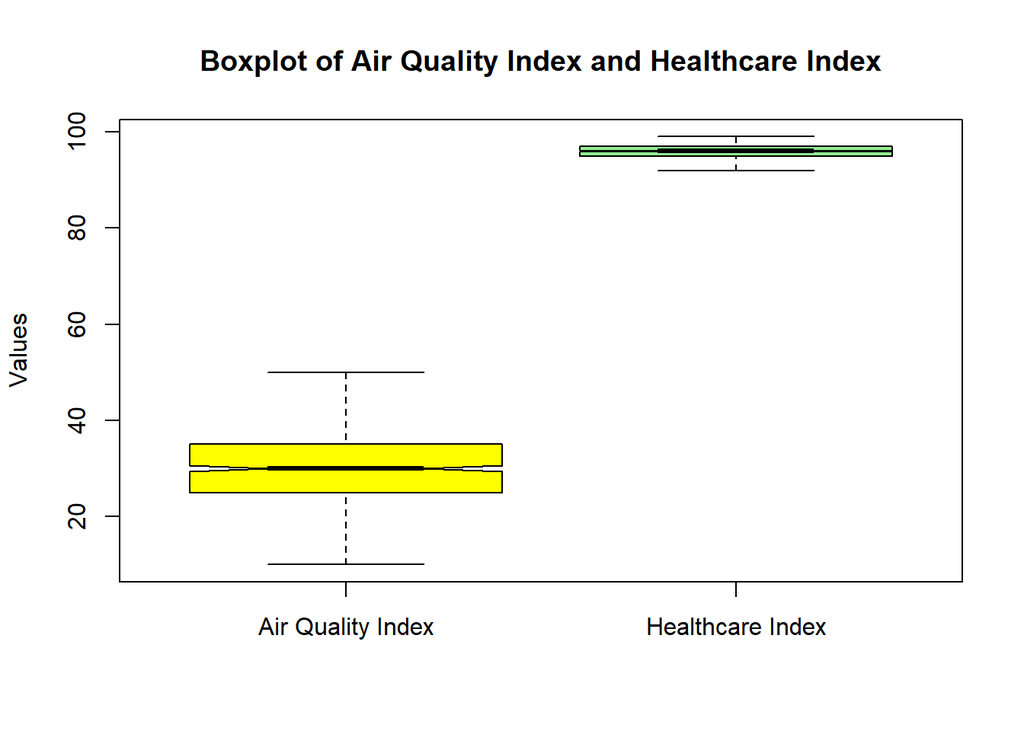

```r
# Box Plotting
boxplot(data$Air_Quality_Index, data$Healthcare_Index,
        names = c("Air Quality Index", "Healthcare Index"),
        main = "Boxplot of Air Quality Index and Healthcare Index",
        ylab = "Values",
        col = c("yellow", "lightgreen"),  # Adjust boxplot colors for better visuality
        border = "black",
        notch = TRUE,
        outline = FALSE)

# Add text with the F-test result to the plot
text(1.5, max(data$Air_Quality_Index),
     paste("F-test p-value:", signif(f_test_result$p.value, digits = 6)),
     pos = 4, col = "red", font = 5, cex = 1.6)  # Adjust text size for better visibility
```

Violin Plot:

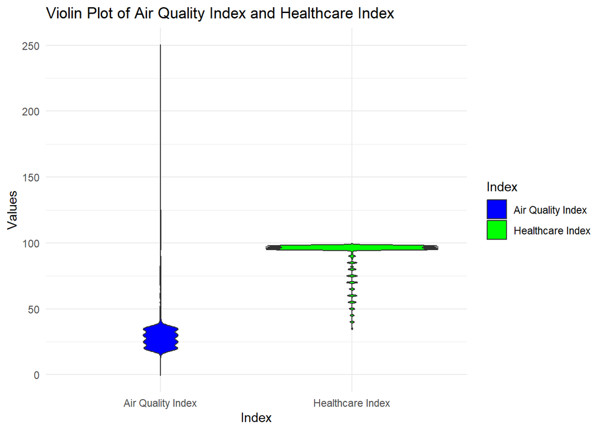

```r
# Perform F-test between Air_Quality_Index and Healthcare_Index
f_test_result <- var.test(data$Air_Quality_Index, data$Healthcare_Index)

install.packages("ggplot2")
library(ggplot2)
library(car)
# Create a data frame for plotting
plot_data <- data.frame(Index = rep(c("Air Quality Index", "Healthcare Index"), each = nrow(data)),
                        Value = c(data$Air_Quality_Index, data$Healthcare_Index))

# Create violin plot
violin <- ggplot(plot_data, aes(x = Index, y = Value, fill = Index)) +
  geom_violin(trim = FALSE) +
  scale_fill_manual(values = c("blue", "green")) +
  labs(title = "Violin Plot of Air Quality Index and Healthcare Index",
       y = "Values") +
  theme_minimal()

# Print the plot
print(violin)
```

```r
# Add text with the F-test result to the plot
p_value_text <- paste("F-test p-value:", signif(f_test_result$p.value, digits = 4))
violin_with_text <- violin +
  annotate("text", x = 1.5, y = max(plot_data$Value), label = p_value_text, hjust = 0.5, vjust = -0.5, size = 4)
```

The violin plot in the image visually compares the distribution of the Air Quality Index and the Healthcare Index.

Violin Shape: The plot is named for its shape, which resembles a violin. The width of each “violin” represents the density of data points at different values, with the widest section indicating the highest density of data.

Air Quality Index: The blue violin on the left represents the Air Quality Index. The distribution is quite wide at the lower end, suggesting that there are many observations with lower Air Quality Index values. There are fewer observations as the index value increases, which is shown by the narrowing of the violin shape. The presence of a wider portion at the bottom indicates a high density of lower values in the data.

Healthcare Index: The green violin on the right represents the Healthcare Index. This distribution is very narrow and centered around a specific range of values, which suggests that most of the Healthcare Index values are clustered around the median, indicating less variability compared to the Air Quality Index.

The violin plot suggests that the Air Quality Index has a broader and more varied distribution of values, with a tendency towards the lower end, while the Healthcare Index values are more tightly clustered around the median, indicating a more uniform distribution within the dataset.

Density Plot:

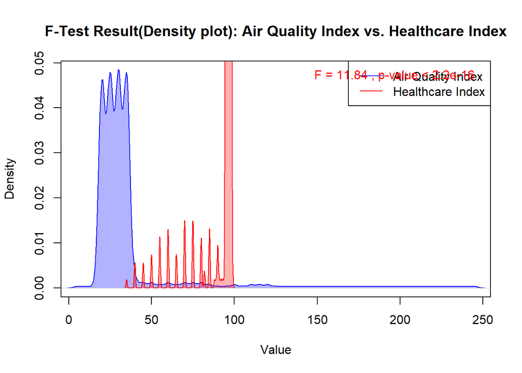

```r
plot_f_test_result <- function(data) {
  # Define variables
  var1 <- data$Air_Quality_Index
  var2 <- data$Healthcare_Index
  f_value <- 11.839
  p_value <- 2.2e-16

  # Create plot
  plot(density(var1), col = "blue", main = "F-Test Result(Density plot): Air Quality Index vs. Healthcare Index",
       xlab = "Value", ylab = "Density", xlim = c(min(c(var1, var2)), max(c(var1, var2))))
  polygon(density(var1), col = rgb(0, 0, 1, alpha = 0.3), border = NA)  # Fill density area with blue color
  lines(density(var2), col = "red")
  polygon(density(var2), col = rgb(1, 0, 0, alpha = 0.3), border = NA)  # Fill density area with red color

  # Add legend
  legend("topright", legend = c("Air Quality Index", "Healthcare Index"), col = c("blue", "red"), lty = 1)

  # Add F-test result annotation
  if (p_value < 0.05) {
    text(x = max(c(var1, var2)), y = max(density(var1)$y),
         labels = paste("F =", round(f_value, 2), ", p-value <", p_value),
         adj = c(1, 1), col = "red")
  } else {
    text(x = max(c(var1, var2)), y = max(density(var1)$y),
         labels = paste("F =", round(f_value, 2), ", p-value =", p_value),
         adj = c(1, 1), col = "green")
  }
}

# Call plot function
plot_f_test_result(data)
```

Additionally, the graph’s title indicates that this is an “F-Test Result:”Comparing Air Quality Index with Healthcare Index” is our analysis title and a legend that obtains an F-statistic of F-statistic which is 11.84 and p-value being less than 2.2e-16, that is virtually zeros.